## Lecture 12 : International Investing with Currency Risk and Return

# Long-term performance of intl. diversification

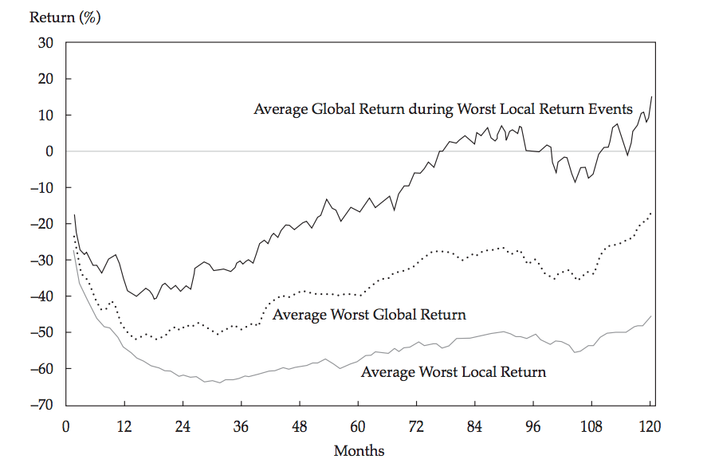

# International investing

- We know that adding assets to a portfolio can reduce variance
  - The CAPM market portfolio included all available assets
- Only question: how much to weight the assets?
  - In equilibrium, market weights are informative
  - Apply this logic to international markets

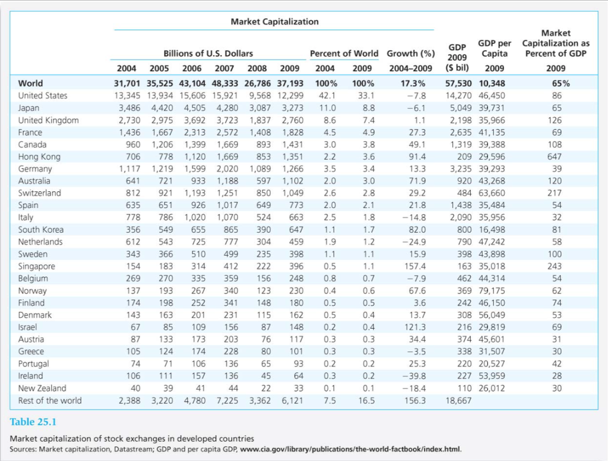

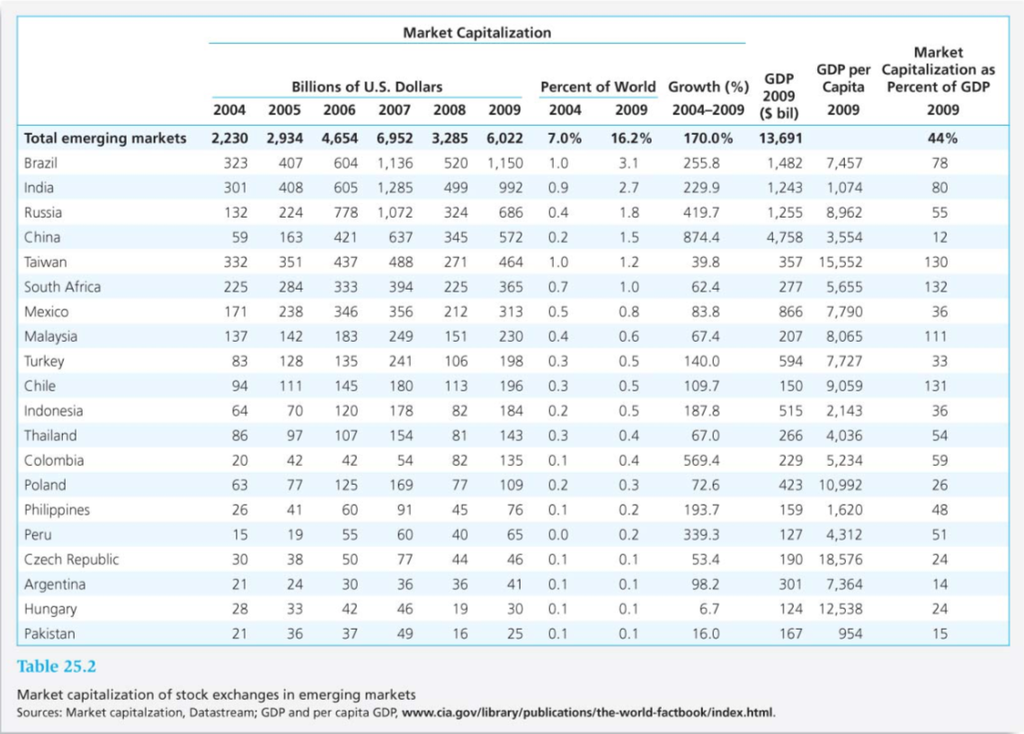

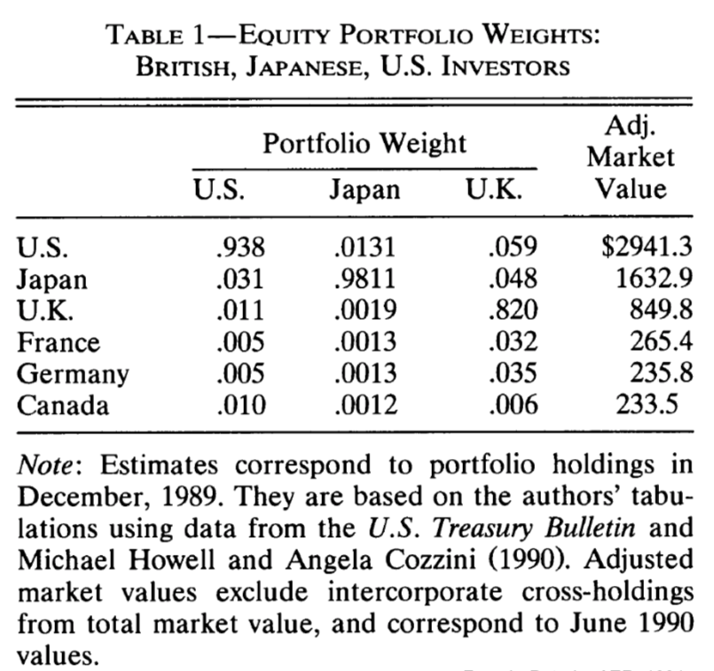

# Home bias

- True in more recent data too
- U.S. investors held 78% of their equity portfolio in U.S. stocks
- Canadian investors held 76% in Canadian Stocks
- German investors held 51% in German Stocks
- UK investors held 61% in U.K. stocks
- Improvement, but still lots of room for growth

# Is the international “market portfolio”" sensible?

- There are reasons why to not hold the “market”
- In many jurisdictions, taxes and other regulations favor local investors over foreign
  - This will distort equilibrium market weights
- CAPM also assumes all investors face identical expected returns and covariances
  - What about exchange rate volatility? Inflation?
  - If we consume in local currency, investors in different countries may face different optimization problems

# Impact of FX and Returns

- Consider the impact of exchange rate movement on dollar denominated stock returns

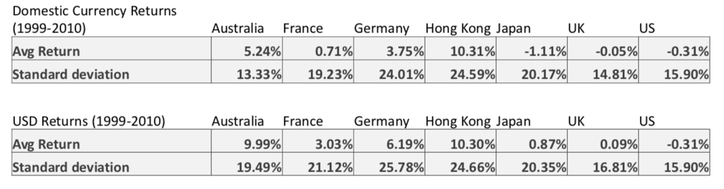

- Foreign currency appreciation( USD depreciation) has bolstered foreign returns over this decade

# Hedging Exchange Rate Risk

- Hedging exchange rate risk is straightforward given a currency futures market when returns are riskless
  - More difficult when returns are risky
- To do so, we need to understand the basics of futures/forward contracts

# Forwards and Futures

- A forward contract is a commitment to purchase/sell at a future date a given amount of an asset at a price agreed upon today
  - Currencies, commodities, equities/indices, rates
- $F_{0}$ is the forward price and represents the fixed price (agreed at t=0) for a future exchange
- $S_{0}$ represents the spot price prevailing today, $S_{T}$ represents spot price at future date $T$
- Note: both parties bound to contract; no option value

# Forwards and Futures Payoff

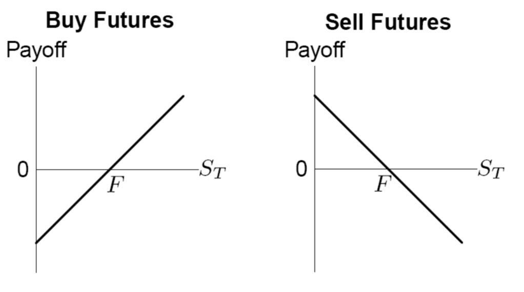

# Forwards and Futures Payoff

- To buy a future/forward contract is to be long on the asset
  - Obligation to buy
  - Payoff is $S_{T}‐F_{0}$
- To sell a future/forward contract is to be short on the asset
  - Obligation to sell
  - Payoff is $F_{0}-S_{T}$
- Key differences between forwards and futures…

# Forward Transaction

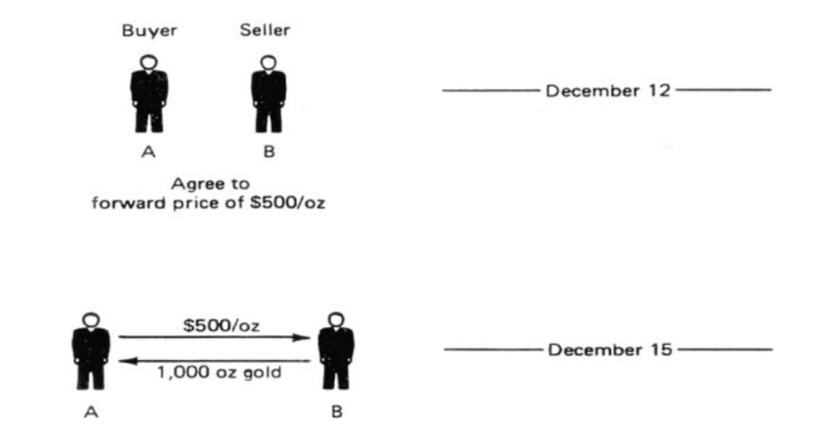

# Future Transaction

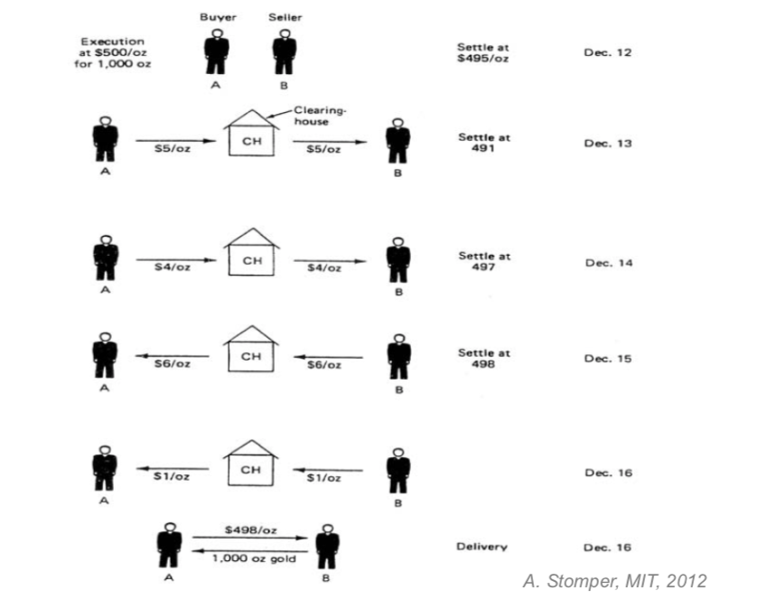

# Pricing FX Forwards/Futures

- Consider the following strategy
1. Buy 1 Australian Dollar at $S_{0}$ (USD/AUS), financed at $(1+r_{us})$
2. Invest in risk-free Australian Bond at $(1+r_{AUS})^{T}$
3. Sell $(1+r_{AUS})^{T}$ futures contract at futures price $F_{0}$ (USD/AUS)

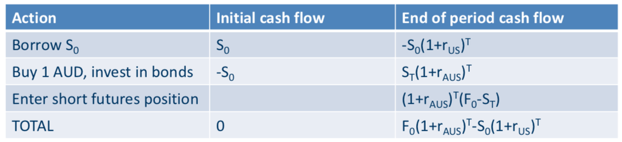

# FX Forwards

- This implies

$$F_{0,T} = S_{0}\left(\frac{1+r_{local}}{1+r_{foreign}}\right)^{T},$$

where the spot price is quoted in local currency per unit of foreign currency

- This relationship is called “covered interest rate parity”
  - Says a hedged investment in risk free foreign bonds only earns the local risk free return
  - Should hold exactly by no arbitrage
- Question: What happens if you don’t hedge?

# The Carry Trade

- The carry trade borrows in low interest rate currencies and lends in high interest rate currencies
- Profitable if either
  1. exchange rates remain unchanged
  2. high interest rate currency appreciates
- Alternatively, instead of borrowing and lending, use the futures market
- Buying futures contracts is equivalent to borrowing $S_{0}$ locally and lending in the foreign market
  - you can verify this by examining the cash flows from the hedged borrowing/lending strategy
- Higher foreign interest rates implies $F_{0} < S_{0}$ (forward discount)
- As long as exchange rates are unchanged, this is profitable

# The Carry Trade

- Another parity theorem predicts that this won’t work
- Uncovered interest rate parity suggests

$$E(S_{T}) = S_{0}\left(\frac{1+r_{local}}{1+r_{foreign}}\right)^{T} = F_{0}$$

- The theorem says investors will only buy low (high) interest rates currencies if they expect them to appreciate (depreciate)
- **Covered interest rate parity** says the riskless (hedged) trade is unprofitable
- **Uncovered interest rate parity** says even the risky (unhedged) trade is unprofitable

# The Carry Trade

- Theoretical implications of uncovered interest rate parity
  1. Futures price equals expected spot price
  2. Interest rate differentials offset by expected changes in spot price

$$(1+r_{us}) = (1+r_{foreign})(1 + r_{FX})$$

- These suggest the carry trade should only break even on average

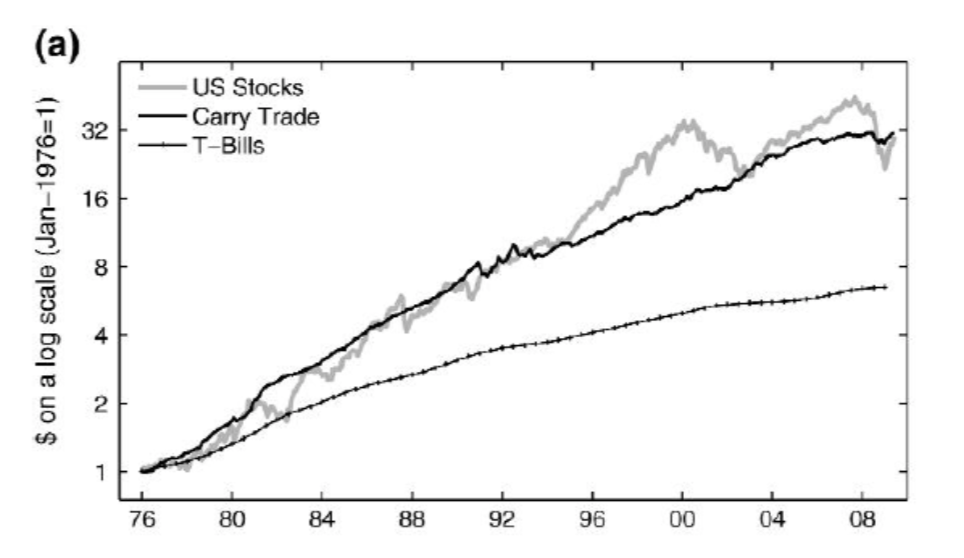

# The Carry Trade

- UIP predicts low interest rate currency will appreciate relative to high
- Consistently, this result fails to deliver – Instead, low interest rate currencies typically depreciate as traders borrow (short) these currencies to lend (buy) in high yielding currencies
- Carry trade profits from interest rate spread and currency appreciation

# The Carry Trade

- UIP relies on risk neutrality - risk aversion may help explain carry returns
- Burnside (2011) finds low market loadings, high alpha from a CAPM regression
- Menhoff, Sarno, Schmeling, and Schrimpf (2011) suggest carry trade does poorly in currency crises
- Still largely unexplained – tied to many extreme “tail” events. Unwinding during currency crises, financial crisis, etc.

# Review Problems

1. What are the two types of risk embedded in a return? How would you measure these in a CAPM regression?
2. What is the capital allocation line? What feature of it do you want to maximize?
3. What are the types of ways of evaluating an investment or investment manager? What scenarios are these most appropriate?
4. Draw the security market line. Under the CAPM, where should stocks lie?
5. You’ve described the CAPM model to a friend and they looked up evidence showing how it fails. Describe some of the reasons why the CAPM might not hold. What are reasons it might still be useful?
6. You are a graduate of Yale SOM, with a relatively high-paying and secure (i.e. low risk) job in the near-future. How should your investment strategy compare someone with a future job profile that is higher risk? Explain why.
7. Explain why an investor can’t just use Markowitz portfolio optimization for finding the optimal portfolio of risky assets. What are some solutions?
8. List what you think are the main benefits of finanicial investment. Which of these can an institutional investor achieve? Which can an individual investor?